# Project5- Zhenning

# Identify Enron Fraud

```python
cd "C:\Users\Zhenning\Desktop\Code\DA_Nanodegree\Project5\ud120-projects\final_project"
```

```
C:\Users\Zhenning\Desktop\Code\DA_Nanodegree\Project5\ud120-projects\final_project
```

```python
# %load poi_id.py
#!/usr/bin/python

import sys
import pickle
sys.path.append("../tools/")

from feature_format import featureFormat, targetFeatureSplit
from tester import dump_classifier_and_data
import matplotlib.pyplot as plt
%matplotlib inline
from pprint import pprint
```

```python
from sklearn.cross_validation import StratifiedShuffleSplit


PERF_FORMAT_STRING = "\
\tAccuracy: {:>0.{display_precision}f}\tPrecision: {:>0.{display_precision}f}\t\
Recall: {:>0.{display_precision}f}\tF1: {:>0.{display_precision}f}\tF2: {:>0.{display_precision}f}"
RESULTS_FORMAT_STRING = "\tTotal predictions: {:4d}\tTrue positives: {:4d}\tFalse positives: {:4d}\
\tFalse negatives: {:4d}\tTrue negatives: {:4d}"

def test_classifier(clf, dataset, feature_list, folds = 1000):
    data = featureFormat(dataset, feature_list, sort_keys = True)
    labels, features = targetFeatureSplit(data)
    cv = StratifiedShuffleSplit(labels, folds, random_state = 42)
    true_negatives = 0
    false_negatives = 0
    true_positives = 0
    false_positives = 0
    for train_idx, test_idx in cv:
        features_train = []
        features_test  = []
        labels_train   = []
        labels_test    = []
        for ii in train_idx:
            features_train.append( features[ii] )
            labels_train.append( labels[ii] )
        for jj in test_idx:
            features_test.append( features[jj] )
            labels_test.append( labels[jj] )

        ### fit the classifier using training set, and test on test set
        clf.fit(features_train, labels_train)
        predictions = clf.predict(features_test)
        for prediction, truth in zip(predictions, labels_test):
            if prediction == 0 and truth == 0:
                true_negatives += 1
            elif prediction == 0 and truth == 1:
                false_negatives += 1
            elif prediction == 1 and truth == 0:
                false_positives += 1
            elif prediction == 1 and truth == 1:
                true_positives += 1
            else:
                print "Warning: Found a predicted label not == 0 or 1."
                print "All predictions should take value 0 or 1."
                print "Evaluating performance for processed predictions:"
                break
    try:
        total_predictions = true_negatives + false_negatives + false_positives + true_positives
        accuracy = 1.0*(true_positives + true_negatives)/total_predictions
        precision = 1.0*true_positives/(true_positives+false_positives)
        recall = 1.0*true_positives/(true_positives+false_negatives)
        f1 = 2.0 * true_positives/(2*true_positives + false_positives+false_negatives)
        f2 = (1+2.0*2.0) * precision*recall/(4*precision + recall)
        print clf
        print PERF_FORMAT_STRING.format(accuracy, precision, recall, f1, f2, display_precision = 5)
        print RESULTS_FORMAT_STRING.format(total_predictions, true_positives, false_positives, false_negatives, true_negatives)
        print ""
    except:
        print "Got a divide by zero when trying out:", clf
        print "Precision or recall may be undefined due to a lack of true positive predicitons."
```

# 1. Understand the dataset and question

## 1.1 Data exploration

```python
### Load the dictionary containing the dataset
with open("final_project_dataset.pkl", "r") as data_file:
    data_dict = pickle.load(data_file)
```

```python
### Explore dataset
num_data_points = len(data_dict)
print "total number of data points:", num_data_points
```

```
total number of data points: 146
```

```python
people = [key for key in data_dict]
#print people
print "Structure of the data points:"
pprint(data_dict['METTS MARK'])  # check the structure of the data points using one person as an example
```

```
Structure of the data points:
{'bonus': 600000,
 'deferral_payments': 'NaN',
 'deferred_income': 'NaN',
 'director_fees': 'NaN',
 'email_address': 'mark.metts@enron.com',
 'exercised_stock_options': 'NaN',
 'expenses': 94299,
 'from_messages': 29,
 'from_poi_to_this_person': 38,
 'from_this_person_to_poi': 1,
 'loan_advances': 'NaN',
 'long_term_incentive': 'NaN',
 'other': 1740,
 'poi': False,
 'restricted_stock': 585062,
 'restricted_stock_deferred': 'NaN',
 'salary': 365788,
 'shared_receipt_with_poi': 702,
 'to_messages': 807,
 'total_payments': 1061827,
 'total_stock_value': 585062}
```

```python
# find all the features
all_features = [key for key in data_dict['METTS MARK']]
print "all features:"
pprint (all_features)
print "total number of features:", len(all_features)
```

```
all features:
['salary',
 'to_messages',
 'deferral_payments',
 'total_payments',
 'exercised_stock_options',
 'bonus',
 'restricted_stock',
 'shared_receipt_with_poi',
 'restricted_stock_deferred',
 'total_stock_value',
 'expenses',
 'loan_advances',
 'from_messages',
 'other',
 'from_this_person_to_poi',
 'poi',
 'director_fees',
 'deferred_income',
 'long_term_incentive',
 'email_address',
 'from_poi_to_this_person']
total number of features: 21
```

```python
# There are missing values in some fields. Find out the percentage of missing values in each feature
missing_value = []

for feature in all_features:
    count = 0
    for k in data_dict:
        if data_dict[k][feature] == "NaN":
            count +=1
    percentage = 1.0*count / num_data_points
    missing_value.append((feature, round(percentage,3)))
```

```python
missing_value.sort(key = lambda tup: tup[1], reverse = False)
pprint (missing_value)
```

[output not shown]

### There are missing values in all features, except the class label 'poi'. I will pay attention to the features with a large percentage of missing values during feature selection and try not to include them in the final model.

```python
# find the number of poi and non-POI
print "number of POI:", len( [person for person in data_dict if data_dict[person]["poi"] == True ])
print "number of non-POI:", len( [person for person in data_dict if data_dict[person]["poi"] == False ])
```

```
number of POI: 18
number of non-POI: 128
```

```python
# calculate the majority class prediction for this highly imbalanced dataset
print "majority class prediciton accuracy:", 128./146
```

```
majority class prediciton accuracy: 0.876712328767
```

## 1.2 Examine outliers

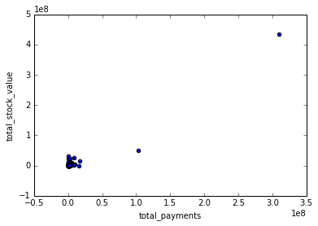

```python
### Task 2: Remove outliers
# find outliers
features = ['total_payments', "total_stock_value"]
data = featureFormat(data_dict, features)

for point in data:
    xp = point[0]
    yp = point[1]
    plt.scatter( xp, yp )
    if xp > 2e7:
        outlier = xp

plt.xlabel(features[0])
plt.ylabel(features[1])
plt.show()
```

### The "total" data point appears as the outlier and is not a real data point for analysis. Remove the "total" data point

```python
for k, v in data_dict.items():
    if v["total_payments"] == outlier:
        print k, v

# remove the "total" data point outlier
data_dict.pop("TOTAL")
print "number of data_points after removing oulier:", len(data_dict)
```

```
TOTAL {'salary': 26704229, 'to_messages': 'NaN', 'deferral_payments': 32083396, 'total_payments': 309886585, 'exercised_stock_options': 311764000, 'bonus': 97343619, 'restricted_stock': 130322299, 'shared_receipt_with_poi': 'NaN', 'restricted_stock_deferred': -7576788, 'total_stock_value': 434509511…
number of data_points after removing oulier: 145
```

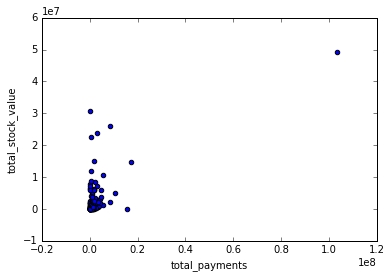

```python
# re-visualize scatter plot after removing the "total" data point
data = featureFormat(data_dict, features)

for point in data:
    xp = point[0]
    yp = point[1]
    plt.scatter( xp, yp )
    if xp > 2e7:
        outlier = xp

plt.xlabel(features[0])
plt.ylabel(features[1])
plt.show()
```

### There is one more data point with very high total payment and total stock value. Find out if it's another irrelavent input or an extreme case of real data point

```python
for k, v in data_dict.items():
    if v["total_payments"] > 1e8 and v["total_payments"] != "NaN":
        print k, v
```

```
LAY KENNETH L {'salary': 1072321, 'to_messages': 4273, 'deferral_payments': 202911, 'total_payments': 103559793, 'exercised_stock_options': 34348384, 'bonus': 7000000, 'restricted_stock': 14761694, 'shared_receipt_with_poi': 2411, 'restricted_stock_deferred': 'NaN', 'total_stock_value': 49110078, 'e…
```

### This person is Kenneth Lay, CEO of Enron, which makes sense that he had a very high total payment and stock value. Since this is a real data point, I will keep it for analysis.

# 2. Feature engineering and selection

## 2.1 Feature engineering

### Since email communication with POIs can indicate the person's involvement in the fraud, I multiplied the number of emails from a person to POI and that from POI to this person to create a new feature called poi_email that amplifies the effect of a person's email communication with POI on identification

```python
### Task 3: Create new feature(s)

for k in data_dict:
    data_point = data_dict[k]
    if data_point["from_this_person_to_poi"] == "NaN" or data_point["from_poi_to_this_person"] == "NaN":
        data_point["poi_email"] = 0
    else:
        data_point["poi_email"] = int(data_point["from_this_person_to_poi"])* int(data_point["from_poi_to_this_person"])
```

```python
for k in data_dict:
    data_point = data_dict[k]
    if data_point["exercised_stock_options"] =="NaN" or data_point["total_stock_value"] == "NaN":
        data_point["exercised_stock_option_ratio"] = 0
    else:
        data_point["exercised_stock_option_ratio"] = int(data_point["exercised_stock_options"])* int(data_point["total_stock_value"])
```

```python
# check all the features after feature engineering to ensure the engineered features are included in the dataset
all_features = [key for key in data_dict['METTS MARK']]
print "all features:"
print all_features
print "total number of features:", len(all_features)
```

```
all features:
['to_messages', 'deferral_payments', 'expenses', 'poi', 'deferred_income', 'exercised_stock_option_ratio', 'email_address', 'long_term_incentive', 'restricted_stock_deferred', 'shared_receipt_with_poi', 'poi_email', 'loan_advances', 'from_messages', 'other', 'director_fees', 'bonus', 'total_stock_va…
total number of features: 23
```

```python
### Store to my_dataset for easy export below.
my_dataset = data_dict
```

## 2.2 Feature selection: use a variety of classifiers and different features to select a classifier and features for further tuning. Due to the limited number of data points and highly imbalanced classes, I use "StratifiedShuffleSplit" to create multiple folds of train and test data and calculate the average accuracy, precision and recall from all folds. This will give a more objective evaluation of the model. I took advantage of the "test_classifier" function written in the tester.py

### First, try all the features with numeric data, excluding "email address"

```python
feature_list = ['poi', 'to_messages', 'deferral_payments', 'expenses',  'deferred_income',
                'exercised_stock_option_ratio',  'long_term_incentive',
                'restricted_stock_deferred', 'shared_receipt_with_poi', 'poi_email', 'loan_advances',
                'from_messages', 'other', 'director_fees', 'bonus', 'total_stock_value',
                'from_poi_to_this_person', 'from_this_person_to_poi', 'restricted_stock',
                'salary', 'total_payments', 'exercised_stock_options']
```

```python
print len(feature_list)
```

```
22
```

```python
from sklearn.feature_selection import SelectKBest, f_classif
from sklearn.pipeline import Pipeline
from sklearn.preprocessing import MinMaxScaler
from sklearn.grid_search import GridSearchCV
```

```python
scaler = MinMaxScaler()
select_filter = SelectKBest (f_classif)
```

```python
from sklearn.naive_bayes import GaussianNB
clf = GaussianNB()
pipeline_NB = Pipeline([("filter", select_filter),
                       ("classifier", clf) ])
test_classifier(pipeline_NB, my_dataset, feature_list, folds = 100)
```

```
Pipeline(steps=[('filter', SelectKBest(k=10, score_func=<function f_classif at 0x0000000009594AC8>)), ('classifier', GaussianNB())])
	Accuracy: 0.88800	Precision: 0.71053	Recall: 0.27000	F1: 0.39130	F2: 0.30822
	Total predictions: 1500	True positives:   54	False positives:   22	False negatives:  146	True negatives: 1278
```

```python
parameters = { "filter__k": [4,5,6,7,8,9,10]

}

data = featureFormat(my_dataset, feature_list, sort_keys = True)
labels, features = targetFeatureSplit(data)

sss = StratifiedShuffleSplit(labels,  n_iter=100, random_state = 42)
```

```python
gs = GridSearchCV(pipeline_NB, param_grid= parameters, scoring = 'f1', cv =sss ) # F1 score is a combination of precision and recall
```

```python
gs.fit(features, labels)
```

```
GridSearchCV(cv=StratifiedShuffleSplit(labels=[ 0.  0. ...,  1.  0.], n_iter=100, test_size=0.1, random_state=42),
       error_score='raise',
       estimator=Pipeline(steps=[('filter', SelectKBest(k=10, score_func=<function f_classif at 0x0000000009594AC8>)), ('classifier', GaussianNB())]),
       fit_params={}, iid=True, n_jobs=1,
       param_grid={'filter__k': [4, 5, 6, 7, 8, 9, 10]},
       pre_dispatch='2*n_jobs', refit=True, scoring='f1', verbose=0)
```

```python
print "Best estimator found by grid search:"
NB = gs.best_estimator_
print NB
```

```
Best estimator found by grid search:
Pipeline(steps=[('filter', SelectKBest(k=7, score_func=<function f_classif at 0x0000000009594AC8>)), ('classifier', GaussianNB())])
```

```python
features_selected_bool = gs.best_estimator_.named_steps['filter'].get_support()
features_selected_list = [x for x, y in zip(feature_list[1:], features_selected_bool) if y]
print features_selected_list
```

```
['deferred_income', 'exercised_stock_option_ratio', 'long_term_incentive', 'bonus', 'total_stock_value', 'salary', 'exercised_stock_options']
```

```python
scores = gs.best_estimator_.named_steps['filter'].scores_
print scores
```

```
[  1.69882435   0.21705893   6.23420114  11.59554766  24.26781551
  10.07245453   0.06498431   8.74648553   0.03006828   7.2427304
   0.1641645    4.20497086   2.10765594  21.06000171  24.46765405
   5.34494152   2.42650813   9.34670079  18.57570327   8.86672154
  25.09754153]
```

```python
for feature, score in zip(feature_list[1:], scores):
    if feature in features_selected_list:
        print feature, round(score,3)
```

[output not shown]

```python
#test the performance with best selected features
test_classifier(NB, my_dataset, feature_list, folds = 100)
```

[output not shown]

## The above 7 features have the highest weight for Naive Bayes Classifier. Next, explore K Nearest Neighbors (KNN) Classifier for feature selection

```python
from sklearn.neighbors import KNeighborsClassifier

KNN = KNeighborsClassifier()
pipeline_KNN = Pipeline([("scaler", scaler),
                         ("filter", select_filter),
                        ("classifier", KNN)])
test_classifier(pipeline_KNN, my_dataset, feature_list, folds = 100)
```

```
Pipeline(steps=[('scaler', MinMaxScaler(copy=True, feature_range=(0, 1))), ('filter', SelectKBest(k=10, score_func=<function f_classif at 0x0000000009594AC8>)), ('classifier', KNeighborsClassifier(algorithm='auto', leaf_size=30, metric='minkowski',
           metric_params=None, n_jobs=1, n_neighbors=5, p=2,
           weights='uniform'))])
	Accuracy: 0.86000	Precision: 0.38636	Recall: 0.08500	F1: 0.13934	F2: 0.10071
	Total predictions: 1500	True positives:   17	False positives:   27	False negatives:  183	True negatives: 1273
```

```python
parameters = { "filter__k": [2,3,4,5,6,7,10]

}

gs = GridSearchCV(pipeline_KNN, param_grid= parameters, scoring = 'f1', cv =sss )

gs.fit(features,labels)
```

```
GridSearchCV(cv=StratifiedShuffleSplit(labels=[ 0.  0. ...,  1.  0.], n_iter=100, test_size=0.1, random_state=42),
       error_score='raise',
       estimator=Pipeline(steps=[('scaler', MinMaxScaler(copy=True, feature_range=(0, 1))), ('filter', SelectKBest(k=10, score_func=<function f_classif at 0x0000000009594AC8>)), ('classifier', KNeighborsClassifier(algorithm='auto', leaf_size=30, metric='minkowski',
           metric_params=None, n_jobs=1, n_neighbors=5, p=2,
           weights='uniform'))]),
       fit_params={}, iid=True, n_jobs=1,
       param_grid={'filter__k': [2, 3, 4, 5, 6, 7, 10]},
       pre_dispatch='2*n_jobs', refit=True, scoring='f1', verbose=0)
```

```python
print "Best estimator found by grid search:"
KNN_selected_features = gs.best_estimator_
print KNN_selected_features
```

```
Best estimator found by grid search:
Pipeline(steps=[('scaler', MinMaxScaler(copy=True, feature_range=(0, 1))), ('filter', SelectKBest(k=4, score_func=<function f_classif at 0x0000000009594AC8>)), ('classifier', KNeighborsClassifier(algorithm='auto', leaf_size=30, metric='minkowski',
           metric_params=None, n_jobs=1, n_neighbors=5, p=2,
           weights='uniform'))])
```

```python
features_selected_bool = gs.best_estimator_.named_steps['filter'].get_support()
features_selected_list = [x for x, y in zip(feature_list[1:], features_selected_bool) if y]
print features_selected_list
```

```
['exercised_stock_option_ratio', 'bonus', 'total_stock_value', 'exercised_stock_options']
```

```python
scores = gs.best_estimator_.named_steps['filter'].scores_
print scores
```

```
[  1.69882435   0.21705893   6.23420114  11.59554766  24.26781551
  10.07245453   0.06498431   8.74648553   0.03006828   7.2427304
   0.1641645    4.20497086   2.10765594  21.06000171  24.46765405
   5.34494152   2.42650813   9.34670079  18.57570327   8.86672154
  25.09754153]
```

```python
for feature, score in zip(feature_list[1:], scores):
    if feature in features_selected_list:
        print feature, score
```

```
exercised_stock_option_ratio 24.2678155059
bonus 21.0600017075
total_stock_value 24.4676540475
exercised_stock_options 25.0975415287
```

```python
#test the performance with best selected features
test_classifier(KNN_selected_features, my_dataset, feature_list, folds = 100)
```

```
Pipeline(steps=[('scaler', MinMaxScaler(copy=True, feature_range=(0, 1))), ('filter', SelectKBest(k=4, score_func=<function f_classif at 0x0000000009594AC8>)), ('classifier', KNeighborsClassifier(algorithm='auto', leaf_size=30, metric='minkowski',
           metric_params=None, n_jobs=1, n_neighbors=5, p=2,
           weights='uniform'))])
	Accuracy: 0.88200	Precision: 0.68254	Recall: 0.21500	F1: 0.32700	F2: 0.24913
	Total predictions: 1500	True positives:   43	False positives:   20	False negatives:  157	True negatives: 1280
```

## The above 4 features have the highest weight for KNN classifier. However, the performance of KNN is worse than Naive Bayes Classifier. Next, explore Adaboost classifier

```python
from sklearn.ensemble import AdaBoostClassifier

adaboost_clf = AdaBoostClassifier( random_state = 1)
pipeline_Adaboost = Pipeline([("filter", select_filter),
                             ("classifier", adaboost_clf)])
test_classifier(pipeline_Adaboost, my_dataset, feature_list, folds = 100)
```

```
Pipeline(steps=[('filter', SelectKBest(k=10, score_func=<function f_classif at 0x0000000009594AC8>)), ('classifier', AdaBoostClassifier(algorithm='SAMME.R', base_estimator=None,
          learning_rate=1.0, n_estimators=50, random_state=1))])
	Accuracy: 0.83600	Precision: 0.34667	Recall: 0.26000	F1: 0.29714	F2: 0.27368
	Total predictions: 1500	True positives:   52	False positives:   98	False negatives:  148	True negatives: 1202
```

```python
parameters = { "filter__k": [3,6,9,12,15,18]

}

gs = GridSearchCV(pipeline_Adaboost, param_grid= parameters, scoring = 'f1', cv =sss )

gs.fit(features,labels)
```

```
GridSearchCV(cv=StratifiedShuffleSplit(labels=[ 0.  0. ...,  1.  0.], n_iter=100, test_size=0.1, random_state=42),
       error_score='raise',
       estimator=Pipeline(steps=[('filter', SelectKBest(k=10, score_func=<function f_classif at 0x0000000009594AC8>)), ('classifier', AdaBoostClassifier(algorithm='SAMME.R', base_estimator=None,
          learning_rate=1.0, n_estimators=50, random_state=1))]),
       fit_params={}, iid=True, n_jobs=1,
       param_grid={'filter__k': [3, 6, 9, 12, 15, 18]},
       pre_dispatch='2*n_jobs', refit=True, scoring='f1', verbose=0)
```

```python
print "Best estimator found by grid search:"
Adaboost_selected_features = gs.best_estimator_
print Adaboost_selected_features
```

```
Best estimator found by grid search:
Pipeline(steps=[('filter', SelectKBest(k=15, score_func=<function f_classif at 0x0000000009594AC8>)), ('classifier', AdaBoostClassifier(algorithm='SAMME.R', base_estimator=None,
          learning_rate=1.0, n_estimators=50, random_state=1))])
```

```python
features_selected_bool = gs.best_estimator_.named_steps['filter'].get_support()
features_selected_list = [x for x, y in zip(feature_list[1:], features_selected_bool) if y]
print features_selected_list
```

```
['expenses', 'deferred_income', 'exercised_stock_option_ratio', 'long_term_incentive', 'shared_receipt_with_poi', 'loan_advances', 'other', 'bonus', 'total_stock_value', 'from_poi_to_this_person', 'from_this_person_to_poi', 'restricted_stock', 'salary', 'total_payments', 'exercised_stock_options']
```

```python
scores = gs.best_estimator_.named_steps['filter'].scores_
print scores
```

```
[  1.69882435   0.21705893   6.23420114  11.59554766  24.26781551
  10.07245453   0.06498431   8.74648553   0.03006828   7.2427304
   0.1641645    4.20497086   2.10765594  21.06000171  24.46765405
   5.34494152   2.42650813   9.34670079  18.57570327   8.86672154
  25.09754153]
```

```python
for feature, score in zip(feature_list[1:], scores):
    if feature in features_selected_list:
        print feature, score
```

```
expenses 6.23420114051
deferred_income 11.5955476597
exercised_stock_option_ratio 24.2678155059
long_term_incentive 10.0724545294
shared_receipt_with_poi 8.74648553213
loan_advances 7.24273039654
other 4.2049708583
bonus 21.0600017075
total_stock_value 24.4676540475
from_poi_to_this_person 5.34494152315
from_this_person_to_poi 2.42650812724
restricted_stock 9.34670079105
salary 18.575703268
total_payments 8.86672153711
exercised_stock_options 25.0975415287
```

```python
#test the performance with best selected features
test_classifier(Adaboost_selected_features, my_dataset, feature_list, folds = 100)
```

```
Pipeline(steps=[('filter', SelectKBest(k=15, score_func=<function f_classif at 0x0000000009594AC8>)), ('classifier', AdaBoostClassifier(algorithm='SAMME.R', base_estimator=None,
          learning_rate=1.0, n_estimators=50, random_state=1))])
	Accuracy: 0.84267	Precision: 0.39535	Recall: 0.34000	F1: 0.36559	F2: 0.34979
	Total predictions: 1500	True positives:   68	False positives:  104	False negatives:  132	True negatives: 1196
```

## With 15 best selected features, Adaboost Classifier achieved relatively high precision (0.395) and recall (0.34). In the next step, further tune Adaboost Algorithm and compare its performance with the simple Naive Bayes algorithm

## After testing three classifiers with KBestSelect method, I found that the number of best features selected by KBestSelect algorithm depends on the classifier. Naive Bayer Classifier selected 7 best features. KNN Classifier selected 4 best features. Adaboost Classifier selected 15 best features.

# 3 Pick and tune an algorithm

### An algorithm usually takes a few parameters. Tuning the parameters using training data can improve performance on test data. For example, in the ensemble method, Adaboost classifier combines several weak decision tree classifiers. There are several parameters to tune for the Adaboost classifier, including the type of base estimator and the number of base estimators.

```python
feature_list = ['poi'] + features_selected_list
print feature_list
```

```
['poi', 'expenses', 'deferred_income', 'exercised_stock_option_ratio', 'long_term_incentive', 'shared_receipt_with_poi', 'loan_advances', 'other', 'bonus', 'total_stock_value', 'from_poi_to_this_person', 'from_this_person_to_poi', 'restricted_stock', 'salary', 'total_payments', 'exercised_stock_opti…
```

```python
data = featureFormat(my_dataset, feature_list, sort_keys = True)
labels, features = targetFeatureSplit(data)
```

```python
parameters = {"n_estimators": [ 60, 65, 70, 75, 80],
              "learning_rate": [0.1, 1., 10.]
             }
Adaboost = AdaBoostClassifier(random_state = 1)
```

```python
sss = StratifiedShuffleSplit(labels,  n_iter=100, random_state = 42)
```

```python
gs = GridSearchCV(Adaboost, param_grid= parameters, scoring = 'f1', cv =sss ) # F1 score is a combination of precision and recall
```

```python
gs.fit(features, labels)
```

```
GridSearchCV(cv=StratifiedShuffleSplit(labels=[ 0.  0. ...,  1.  0.], n_iter=100, test_size=0.1, random_state=42),
       error_score='raise',
       estimator=AdaBoostClassifier(algorithm='SAMME.R', base_estimator=None,
          learning_rate=1.0, n_estimators=50, random_state=1),
       fit_params={}, iid=True, n_jobs=1,
       param_grid={'n_estimators': [60, 65, 70, 75, 80], 'learning_rate': [0.1, 1.0, 10.0]},
       pre_dispatch='2*n_jobs', refit=True, scoring='f1', verbose=0)
```

```python
print "Best estimator found by grid search:"
adaboost_clf = gs.best_estimator_
print adaboost_clf
```

```
Best estimator found by grid search:
AdaBoostClassifier(algorithm='SAMME.R', base_estimator=None,
          learning_rate=1.0, n_estimators=70, random_state=1)
```

### Apply the best parameters found by grid search algorithm to evaluate the dataset again

```python
#test the performance with best selected features
test_classifier(adaboost_clf, my_dataset, feature_list, folds = 100)
```

```
AdaBoostClassifier(algorithm='SAMME.R', base_estimator=None,
          learning_rate=1.0, n_estimators=70, random_state=1)
	Accuracy: 0.85133	Precision: 0.42675	Recall: 0.33500	F1: 0.37535	F2: 0.35005
	Total predictions: 1500	True positives:   67	False positives:   90	False negatives:  133	True negatives: 1210
```

### After tuning the Adaboost classifier, its performance is improved. F1 score increased from 0.365 to 0.375. Precision is 0.426. Recall is 0.335

```python
clf = adaboost_clf
```

```python
print "==========================="
### Task 5: Tune your classifier to achieve better than .3 precision and recall
### using our testing script. Check the tester.py script in the final project
### folder for details on the evaluation method, especially the test_classifier
### function. Because of the small size of the dataset, the script uses
### stratified shuffle split cross validation. For more info:
### http://scikit-learn.org/stable/modules/generated/sklearn.cross_validation.StratifiedShuffleSplit.html

# Example starting point. Try investigating other evaluation techniques!
from sklearn.cross_validation import train_test_split
features_train, features_test, labels_train, labels_test = \
    train_test_split(features, labels, test_size=0.3, random_state=42)

### Task 6: Dump your classifier, dataset, and features_list so anyone can
### check your results. You do not need to change anything below, but make sure
### that the version of poi_id.py that you submit can be run on its own and
### generates the necessary .pkl files for validating your results.

dump_classifier_and_data(clf, my_dataset, feature_list)
```